# Homework #7: SVM and Calibration

### De-skewing

The SalesPrice variable is not normally distributed. A Box Cox transformation is applied to skew it to a gaussian distribution.

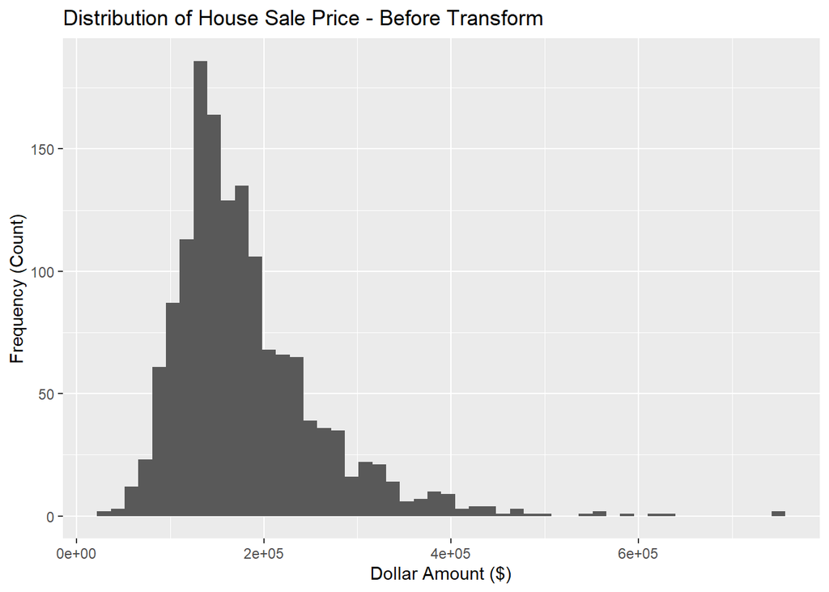

```r
train %>%
    ggplot(aes(x=SalePrice)) +
    geom_histogram(bins = 50) +
    labs(title = "Distribution of House Sale Price - Before Transform",
          x = "Dollar Amount ($)", y = "Frequency (Count)")
```

```r
# SalePrice is right skewed, not normal dist

# Box cox xform
boxcox <- BoxCoxTrans(train$SalePrice, lambda = .15)
boxcox
```

```
Box-Cox Transformation

1460 data points used to estimate Lambda

Input data summary:
   Min. 1st Qu.  Median    Mean 3rd Qu.    Max.
  34900  129975  163000  180921  214000  755000

Largest/Smallest: 21.6
Sample Skewness: 1.88

Estimated Lambda: 0.15
With fudge factor, Lambda = 0 will be used for transformations
```

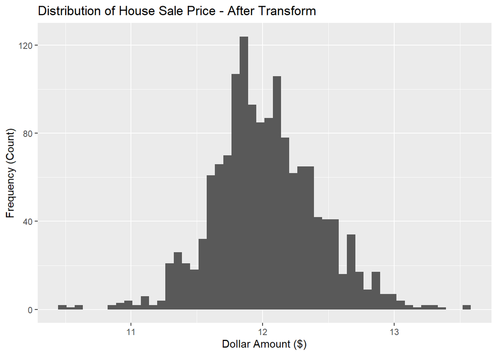

```r
train$SalePrice <- predict(boxcox, train$SalePrice)


train %>%
    ggplot(aes(x=SalePrice)) +
    geom_histogram(bins = 50) +
    labs(title = "Distribution of House Sale Price - After Transform",
          x = "Dollar Amount ($)", y = "Frequency (Count)")
```

```r
# SalePrice now has normal dist
```

### Data Imputation

This section was deprecated; rather than use the MICE package, imputation was done manually above

```r
# Perform multiple imputation
#imputed_data <- mice(data.frame(train)) # m = number of imputations

# Complete the imputed data
#completed_data <- complete(imputed_data)

# Convert to dataframe
#train <- as.data.frame(completed_data)
#train[is.na(train)] = FALSE

# TEST
#imputed_data2 <- mice(test) # m = number of imputations

# Complete the imputed data
#completed_data2 <- complete(imputed_data2)

# Convert to dataframe
#test <- as.data.frame(completed_data2)
#test[is.na(test)] = FALSE
#test
```

## Ensemble Models

**Models to predict SalePrice for Test set and evaluate the RMSE score**

The ensemble model consists of the averaged result of Random Forest, Lasso, and Gradient Boosted regressions

### Random Forest

```r
set.seed(345)

nrow(train)
```

```
[1] 1460
```

```r
nrow(test)
```

```
[1] 1459
```

```r
rf_grid <- expand.grid(mtry=c(1:10),
                       splitrule="extratrees",
                       min.node.size=c(1,5,10,15,20))


tr_ctrl <- trainControl(method="cv",
                        number=5)

# Loop through combination of min.bucket vals
rmse_values <- c()

set.seed(345)
fit_rf <- train(SalePrice ~ ., data=train,
                method="ranger",
                trControl=tr_ctrl,
                num.trees=500,
                tuneGrid=rf_grid)


# best RF tune
print("Best RF tune:")
```

```
[1] "Best RF tune:"
```

```r
print(fit_rf$bestTune, row.names=FALSE)
```

```
 mtry  splitrule min.node.size
   10 extratrees             1
```

```r
# RF predictions
rf_predictions <- predict(fit_rf, newdata=test)

rf_rmse <- min(fit_rf$results$RMSE)
print("RF RMSE:")
```

```
[1] "RF RMSE:"
```

```r
rf_rmse
```

```
[1] 0.16
```

###Lasso

```r
set.seed(123)

lasso_grid <- expand.grid(alpha=1, lambda=0.0001)

tr_ctrl <- trainControl(method="repeatedcv",
                        number=10,
                        repeats=2,
                        savePredictions="final")

fit_lasso <- train(SalePrice ~ ., data=train,
                   method="glmnet",
                   trControl=tr_ctrl,
                   tuneGrid=lasso_grid,
                   metric="RMSE")

# best lasso tune
print("Best lasso tune:")
```

```
[1] "Best lasso tune:"
```

```r
print(fit_lasso$bestTune, row.names=FALSE)
```

```
 alpha lambda
     1  1e-04
```

```r
fit_lasso
```

```
glmnet

1460 samples
 243 predictor

No pre-processing
Resampling: Cross-Validated (10 fold, repeated 2 times)
Summary of sample sizes: 1312, 1313, 1315, 1316, 1314, 1315, ...
Resampling results:

  RMSE   Rsquared  MAE
  0.145  0.871     0.0882

Tuning parameter 'alpha' was held constant at a value of 1
Tuning
 parameter 'lambda' was held constant at a value of 1e-04
```

```r
# lasso predictions
lasso_predictions <- predict(fit_lasso, newdata=test)

lasso_rmse <- min(fit_lasso$results$RMSE)
print("Lasso RMSE:")
```

```
[1] "Lasso RMSE:"
```

```r
lasso_rmse
```

```
[1] 0.145
```

```r
#varImp(fit_lasso)
```

The Lasso regression model produced a predicted RMSE of 0.1446131.

### Gradient Boosted

```r
set.seed(234)

#GBM finetuning params
gbm_grid <- expand.grid(n.trees=(0:10)*50,
                         interaction.depth=c(5),
                         shrinkage=c(0.05),
                         n.minobsinnode=c(10))

#GBM training params
tr_ctrl <- trainControl(method="repeatedcv",
                        number=5,
                        repeats=2,
                        verbose=FALSE,
                        allowParallel=TRUE)

fit_gbm <- train(SalePrice ~ ., data=train,
                 method="gbm",
                 metric="RMSE",
                 maximize=FALSE,
                 trControl=tr_ctrl,
                 tuneGrid=gbm_grid,
                 verbose=FALSE)

# best gbm tune
print("Best GBM tune:")
```

```
[1] "Best GBM tune:"
```

```r
print(fit_gbm$bestTune, row.names=FALSE)
```

```
 n.trees interaction.depth shrinkage n.minobsinnode
     500                 5      0.05             10
```

```r
# GBM predictions
gbm_predictions <- predict(fit_gbm, newdata=test)
#print(head(gbm_predictions))

# GBM RMSE
gbm_rmse <- min(fit_gbm$results$RMSE)
print("GBM RMSE:")
```

```
[1] "GBM RMSE:"
```

```r
gbm_rmse
```

```
[1] 0.127
```

The Gradient Boosted regression model produced a predicted RMSE of 0.1267833.

## Model averaging

We used a simple average of the three ensemble models (RandomForest, Gradient Boosted, Lasso) to create the predicted SalePrice values for the ensemble.

```r
submission <- data.frame((lasso_predictions + gbm_predictions + rf_predictions)/3)

colnames(submission)[1] <- "SalePrice"
```

## Submission

```r
#print(head(submission))

write.csv(submission, "6018submission.csv")
```